DAR Coursework Solution

1. Statistical learning methods

Answer(a): Parametric methods, Non-parametric methods may underperform because they don’t make strong assumptions about the mapping function, making them more flexible. However, they require a large amount of data to estimate accurately and can suffer from overfitting in scenarios with a small number of observations and a large number of predictors.

Answer(b): Non-parametric methods, Non-parametric methods have the advantage of utilizing a large sample size and numerous predictors to estimate intricate relationships without being limited by assumptions regarding the functional form. In contrast, parametric methods may face challenges in accurately representing the complexity of the data due to their strict assumptions.

Answer (c) Parametric methods, Parametric techniques rely on a predetermined function form (such as linear), and when this assumption holds true ( in cases of strong linearity), they can yield robust findings even with a limited sample size.

Answer (d) Non-parametric methods, Non-parametric techniques refrain from making strong assumptions regarding the distribution of errors and possess the ability to adjust more effectively to the increased variability present in the data.

2. Linear regression

Answwe (a)

```r
#Answer-
# Install and load the ISLR package
library(ISLR)
data(Auto)

model <- lm(acceleration ~ cylinders, data=Auto)
summary(model)
```

```
##
## Call:
## lm(formula = acceleration ~ cylinders, data = Auto)
##
## Residuals:
##     Min      1Q  Median      3Q     Max
## -5.4778 -1.7428 -0.2428  1.3897  8.7222
##
## Coefficients:
##             Estimate Std. Error t value Pr(>|t|)
## (Intercept)  20.0078     0.4052   49.38   <2e-16 ***
## cylinders    -0.8163     0.0707  -11.54   <2e-16 ***
## ---
## Signif. codes:  0 '***' 0.001 '**' 0.01 '*' 0.05 '.' 0.1 ' ' 1
##
## Residual standard error: 2.385 on 390 degrees of freedom
## Multiple R-squared:  0.2547, Adjusted R-squared:  0.2528
## F-statistic: 133.3 on 1 and 390 DF,  p-value: < 2.2e-16
```

Answer i. -There exists a correlation between the predictor variable (cylinders) and the response variable (acceleration). This is evident from the noteworthy p-value linked to the coefficient for cylinders (p < 0.001).

Answer ii. - The R-squared value of 0.2547 implies that roughly 25.47% of the variation in acceleration can be attributed to the number of cylinders in the model.

Answer iv.

```r
#Predicted acceleration for cylinders = 3.0
new_data <- data.frame(cylinders = 3.0)
predict(model, newdata = new_data, interval = "prediction", level = 0.99)
```

```
##        fit      lwr      upr
## 1 17.55906 11.36164 23.75648
```

Answer (b)

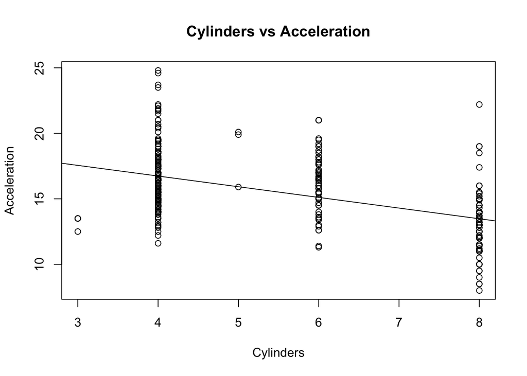

```r
plot(Auto$cylinders,Auto$acceleration,main = "Cylinders vs Acceleration",xlab = "Cylinders",ylab = "Acceleration")
abline(model)
```

Answer (c)

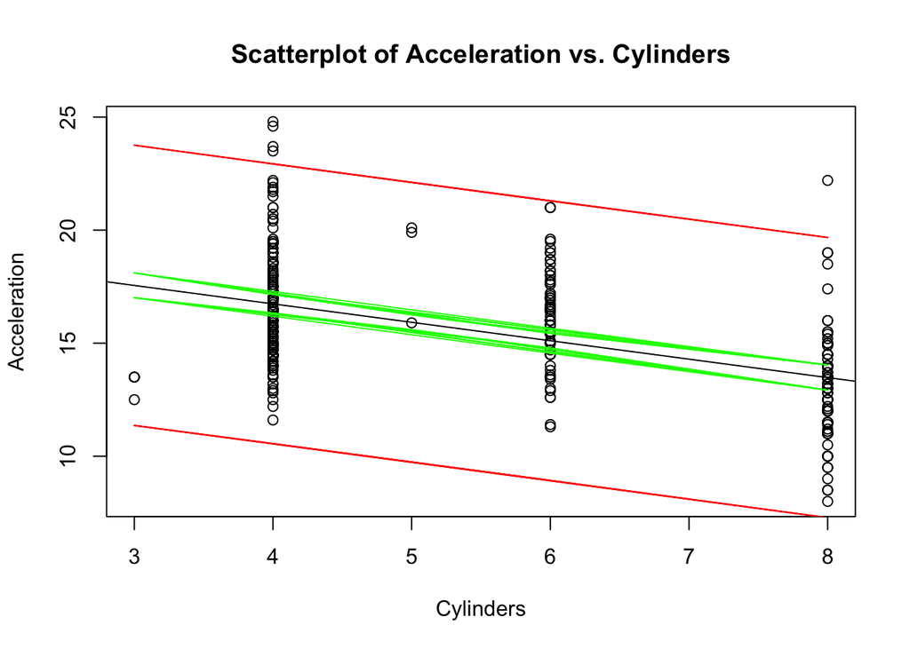

```r
plot(Auto$cylinders, Auto$acceleration, xlab = "Cylinders", ylab = "Acceleration",
     main = "Scatterplot of Acceleration vs. Cylinders")
abline(model)

conf_intr <- predict(model, interval = "confidence", level = 0.99)
pred_intr<- predict(model, interval = "prediction", level = 0.99)

lines(Auto$cylinders, conf_intr[, "lwr"], col = "green")
lines(Auto$cylinders, conf_intr[, "upr"], col = "green")

lines(Auto$cylinders, pred_intr[, "lwr"], col = "red")
lines(Auto$cylinders, pred_intr[, "upr"], col = "red")
```

________________________________________________________________________________________________________________________________________________

```r
#prep data
library(e1071)
library(ROCR)
# Reading the data
training_data <- read.csv('WineQuality_Training.txt', header = TRUE, sep = ",")
test_data <- read.csv('WineQuality_Testing.txt', header = TRUE, sep = ",")

training_data$quality <- as.factor(training_data$quality)
test_data$quality <- as.factor(test_data$quality)
```

Answer a.-

```r
set.seed(1)
tune.grid <- expand.grid(C = c(0.01, 1, 100))
svm_tune <- tune.svm(x = training_data[, -ncol(training_data)],
                     y = training_data$quality,
                     kernel = "linear",
                     cost = tune.grid$C)

svm_model <-  svm_tune$best.model
print(svm_model)
```

```
##
## Call:
## best.svm(x = training_data[, -ncol(training_data)], y = training_data$quality,
##     cost = tune.grid$C, kernel = "linear")
##
##
## Parameters:
##    SVM-Type:  C-classification
##  SVM-Kernel:  linear
##        cost:  1
##
## Number of Support Vectors:  1710
```

Answer b:

```r
svm_linear_model <- svm(quality ~ ., data = training_data, kernel = "linear", cost = 1)

predictions <- predict(svm_linear_model, test_data)
accuracy <- mean(predictions == test_data$quality)
confusion_matrix <- table(predicted = predictions, actual = test_data$quality)
print(confusion_matrix)
```

```
##          actual
## predicted Bad Good
##      Bad  104   89
##      Good  38  169
```

```r
cat("Prediction accuracy:", accuracy,"\n")
```

```
## Prediction accuracy: 0.6825
```

Answer c:

```r
set.seed(1)
ranges <- list(cost = c(0.01, 1, 100), gamma = c(0.01, 1, 100))
svm_cv_r <- tune(svm, quality ~ ., data = training_data, kernel = "radial", ranges = ranges)
summary(svm_cv_r)
```

```
##
## Parameter tuning of 'svm':
##
## - sampling method: 10-fold cross validation
##
## - best parameters:
##  cost gamma
##   100     1
##
## - best performance: 0.1556667
##
## - Detailed performance results:
##    cost gamma     error dispersion
## 1 1e-02 1e-02 0.2826667 0.02647151
## 2 1e+00 1e-02 0.2340000 0.01755415
## 3 1e+02 1e-02 0.2003333 0.03233505
## 4 1e-02 1e+00 0.5060000 0.04870673
## 5 1e+00 1e+00 0.1623333 0.03067351
## 6 1e+02 1e+00 0.1556667 0.02923088
## 7 1e-02 1e+02 0.5120000 0.03103960
## 8 1e+00 1e+02 0.3253333 0.03006988
## 9 1e+02 1e+02 0.3253333 0.03006988
```

Answer d:

```r
svm_model <- svm(quality ~ ., data = training_data, kernel = "radial",cost=100,gamma=1)
predictions <- predict(svm_model, newdata = test_data)
accuracy <- mean(predictions == test_data$quality)
#conf_matrix <- table(Actual = test_data$quality, Predicted = predictions)
#conf_matrix
print(paste("Classification Accuracy:", accuracy))
```

```
## [1] "Classification Accuracy: 0.64"
```

Answer e:

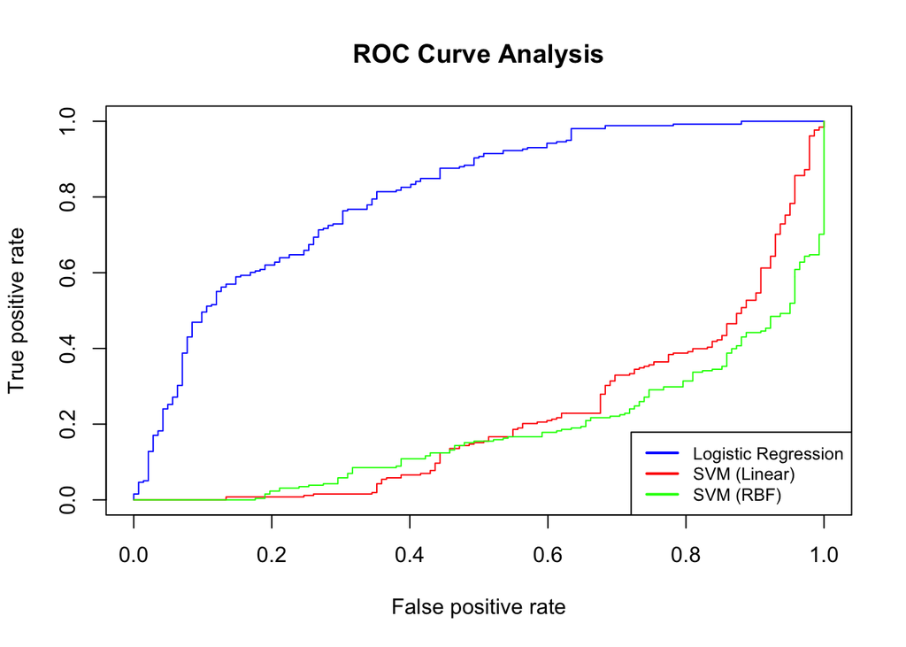

```r
logit_model <- glm(quality ~ ., data = training_data, family = "binomial")
logit_predictions <- predict(logit_model, newdata = test_data, type = "response")

svm_linear_model <- svm(quality ~ ., data = training_data, kernel = "linear", probability = TRUE)
svm_linear_predictions <- attr(predict(svm_linear_model, newdata = test_data, probability = TRUE),
                               "probabilities")

svm_r_model <- svm(quality ~ ., data = training_data, kernel = "radial", probability = TRUE)
svm_r_predictions <- attr(predict(svm_r_model, newdata = test_data, probability = TRUE),
                          "probabilities")

roc_logit <- prediction(logit_predictions, test_data$quality)
roc_svm_linear <- prediction(svm_linear_predictions[,2], test_data$quality)
roc_svm_rbf <- prediction(svm_r_predictions[,2], test_data$quality)

roc_logit_perf <- performance(roc_logit, "tpr", "fpr")
roc_svm_linear_perf <- performance(roc_svm_linear, "tpr", "fpr")
roc_svm_rbf_perf <- performance(roc_svm_rbf, "tpr", "fpr")

plot(roc_logit_perf, col = "blue", main = "ROC Curve Analysis")
plot(roc_svm_linear_perf, col = "red", add = TRUE)
plot(roc_svm_rbf_perf, col = "green", add = TRUE)


legend("bottomright", legend = c("Logistic Regression", "SVM (Linear)", "SVM (RBF)"),
       col = c("blue", "red", "green"), lwd = 2, cex = 0.8)
```